# Modelo de Gestión Integrada del Recurso Hídrico

Proyecto de Series de Tiempo Aplicadas

2025-09-14

## 1. Contexto del Problema

Este análisis busca crear un modelo para predecir la **disponibilidad mensual de agua** (en hm³) en una cuenca rural. A diferencia de un modelo univariado, este utilizará variables externas (regresores) que influyen directamente en la disponibilidad de agua: la **precipitación**, la **evapotranspiración** y el **nivel del embalse**. El modelo a utilizar es un ARIMAX.

## 2. Carga y Preparación de los Datos

Cargamos las librerías y el dataset. Luego, separamos nuestra variable objetivo (`y`) de las variables predictoras (`xreg`) y las convertimos a objetos de series de tiempo (`ts`).

```r
library(tidyverse)
library(fpp2)

# Cargar datos desde la **ruta relativa**
datos_cuenca <- read_csv("data/datos_cuenca_sinu.csv")

# Separar la variable a predecir (y)
disponibilidad_ts <- ts(datos_cuenca$Disponibilidad_Agua_hm3, start = c(2021, 1), frequency = 12)

# Crear una matriz con los regresores externos (xreg)
regresores_externos <- as.matrix(datos_cuenca[, c("Precipitacion_mm", "Evotranspiracion_mm", "Nivel_Embalse_m")])
regresores_ts <- ts(regresores_externos, start = c(2021, 1), frequency = 12)
```

## 3. Construcción del Modelo ARIMAX

Usamos auto.arima() de nuevo, pero esta vez le pasamos nuestras variables predictoras a través del argumento xreg. El modelo buscará la mejor estructura ARIMA después de tener en cuenta el efecto de los regresores.

```r
modelo_arimax <- auto.arima(disponibilidad_ts, xreg = regresores_ts)

print("Resumen del Modelo ARIMAX ajustado:")
```

```
## [1] "Resumen del Modelo ARIMAX ajustado:"
```

```r
summary(modelo_arimax)
```

```
## Series: disponibilidad_ts
## Regression with ARIMA(1,0,0)(1,0,1)[12] errors
##
## Coefficients:
##          ar1    sar1    sma1   intercept  Precipitacion_mm  Evotranspiracion_mm
##       0.3086  0.8392  0.4548  -1241.3775            0.3310              -0.3537
## s.e.  0.1792  0.0926  0.5470    126.3407            0.0537               0.1656
##       Nivel_Embalse_m
##               13.7854
## s.e.           1.2829
##
## sigma^2 = 11.39:  log likelihood = -103.56
## AIC=223.12   AICc=228.45   BIC=235.79
##
## Training set error measures:
##                      ME     RMSE      MAE         MPE     MAPE     MASE
## Training set 0.09333588 3.028797 2.622251 -0.08133336 1.221397 0.170092
##                     ACF1
## Training set -0.04097749
```

El resultado muestra los coeficientes para cada una de las variables predictoras, indicando cómo afectan a la disponibilidad de agua.

## 4. Creación de Escenario Futuro y Predicción

Un punto clave de los modelos ARIMAX: para predecir el futuro de nuestra variable y, necesitamos tener una estimación o un escenario futuro para nuestras variables xreg.

Aquí, crearemos un escenario hipotético para los próximos 6 meses basado en promedios históricos y metas de operación.

```r
# Escenario futuro para los próximos 6 meses (Ene-Jun 2024)
escenario_futuro_xreg <- as.matrix(data.frame(
  Precipitacion_mm = c(40, 35, 60, 180, 250, 280),
  Evotranspiracion_mm = c(100, 110, 125, 120, 100, 95),
  Nivel_Embalse_m = c(105, 104, 103.5, 106, 108, 111)
))

# Generar la predicción usando el escenario futuro
prediccion_arimax <- forecast(modelo_arimax, h = 6, xreg = escenario_futuro_xreg)
```

## 5. Visualización y Conclusiones

Finalmente, visualizamos los datos históricos junto a la predicción generada por el modelo bajo el escenario propuesto.

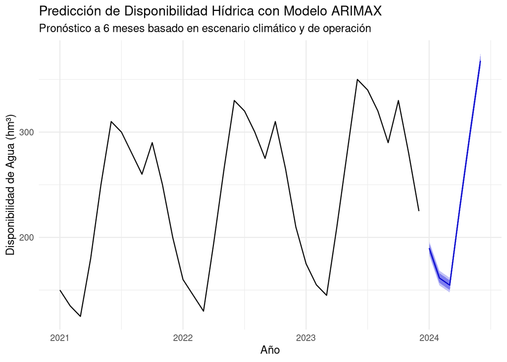

```r
autoplot(prediccion_arimax) +
  labs(
    title = "Predicción de Disponibilidad Hídrica con Modelo ARIMAX",
    subtitle = "Pronóstico a 6 meses basado en escenario climático y de operación",
    x = "Año",
    y = "Disponibilidad de Agua (hm³)"
  ) +
  theme_minimal()
```

Este modelo permite a los gestores de la cuenca simular diferentes escenarios futuros (ej. un “año seco” con baja precipitación) y observar el impacto directo en la disponibilidad de agua, permitiendo una toma de decisiones proactiva y basada en datos.